# Class 08: Text Prediction

```r
library(readr)
library(dplyr)
library(glmnet)
library(ggplot2)
library(stringi)
theme_set(theme_minimal())
```

## Text prediction with Amazon product reviews

Today, we are going to look at a collection of product reviews from Amazon. We will look at this dataset in a few different ways, but today the goal is to predict what category a product is in based on the review (this should be relatively easy). Read in the dataset from my website and remove some of the rows:

```r
amazon <- read_csv("https://statsmaths.github.io/ml_data/amazon_product_class.csv")
amazon <- filter(amazon, !is.na(category), category %in% c(1, 2))
amazon$category <- as.numeric(factor(amazon$category)) - 1L
```

Here is an example of a review from category `0` (books):

```r
stri_wrap(amazon$text[amazon$category == 0][1])
```

```
##  [1] "John Crowley wrote \"Little, Big\", in the words of Michael"
##  [2] "Dirda, book editor of the Washington Post, \"Utterly assured and"
##  [3] "beautiful, it is the greatest fantasy novel so far written by an"
##  [4] "American\" and if memory serves, he went on to say it was \"perhaps"
##  [5] "the best novel written by an American\". Crowley also wrote the"
##  [6] "magnum opus \"Aegypt\", a four volume series with three and a"
##  [7] "half volumes of great story.In \"Four Freedoms\" Crowley shows an"
##  [8] "incredible squandering of his talent. There are literally millions"
##  [9] "of novelists, but very very few quality fantasy writers. After"
## [10] "trudging through about four hundred pages of this weighty tome,"
## [11] "I found there is really nothing here that is not covered in the"
## [12] "paragraph listed above describing the plot. A \"cripple\" and his"
## [13] "various girlfriends, working on a Spruce Goose style mega-airplane"
## [14] "in WWII. No magical realism. Zip. Nada. Also missing is a PLOT,"
## [15] "and a CLIMAX (other than WWII). People listed go to a defense"
```

[output cut: 16 more lines]

And here is category `1` (food):

```r
stri_wrap(amazon$text[amazon$category == 1][1])
```

```
## [1] "At some point I would like to try TeffBob's Red Mill Whole Grain"
## [2] "Teff, 24-Ounce Packages (Pack of 4)I eat lots of Brown Rice"
## [3] "& Quinoa I putRoland Tahini Pure Ground Sesame Seed, 32-Ounce"
## [4] "Container (Pack of 2)on it withReese Artichoke Bottoms, 14-Ounce"
## [5] "Cans (Pack of 12)Carrots & Lettuce YUMMMMMAmaranth is more Woodys"
## [6] "smell but I Like it now! Haven't gotten to a point where I have it"
## [7] "for breakfast..."
```

The difficulty with text prediction is that we need to have a way of constructing a data matrix from raw text. Today, we’ll work with an object called a term frequency matrix; the columns correspond to words and we simply count how often a word is used in a given observation. To build this we need some additional R libraries. We will use the **cleanNLP** package, which you can download with the following code:

```r
if (!require("cleanNLP", quietly = TRUE))
{
  install.packages("cleanNLP")
}
```

Load the package and initalize the tokenizer *backend*; more on back-ends in a later class.

```r
library(cleanNLP)
cnlp_init_tokenizers()
```

Run the function `cnlp_annotate`, followed by `cnlp_get_token`, to extract the individual words from the reviews (this may take a minute or two):

```r
anno <- cnlp_get_token(cnlp_annotate(amazon, text_var = "text"))
```

The output is a data frame, R’s object type for storing tabular data, with one row per word. There are a lot of other columns that are not filled in because we chose a simplistic NLP backend.

```r
anno
```

```
## # A tibble: 722,717 x 8
##    id      sid   tid word      lemma upos  pos     cid
##    <chr> <int> <int> <chr>     <chr> <chr> <chr> <int>
##  1 doc1      1     1 At        <NA>  <NA>  <NA>      1
##  2 doc1      1     2 some      <NA>  <NA>  <NA>      4
##  3 doc1      1     3 point     <NA>  <NA>  <NA>      9
##  4 doc1      1     4 I         <NA>  <NA>  <NA>     15
##  5 doc1      1     5 would     <NA>  <NA>  <NA>     17
##  6 doc1      1     6 like      <NA>  <NA>  <NA>     23
##  7 doc1      1     7 to        <NA>  <NA>  <NA>     28
##  8 doc1      1     8 try       <NA>  <NA>  <NA>     31
##  9 doc1      1     9 TeffBob's <NA>  <NA>  <NA>     35
## 10 doc1      1    10 Red       <NA>  <NA>  <NA>     45
## # … with 722,707 more rows
```

To turn this into a term frequency matrix, call `cnlp_utils_tfidf`; the options in the call determine what words are included (a word must be used in at least `mid_df` percent of documents but not in more than `max_df` documents):

```r
X <- cnlp_utils_tfidf(anno, min_df = 0.01, max_df = 0.5, tf_weight = "raw", token_var = "word")
```

Here are the first few columns and rows of the dataset:

```r
as.matrix(X[1:10, 1:10])
```

```
##               -     with      was        "     book       as      but
## doc1   4.008028 0.000000 0.000000  0.00000 0.000000 0.000000 1.089864
## doc2   1.336009 2.110536 4.117842 31.11485 1.477286 0.000000 3.269591
## doc3   1.336009 3.165804 0.000000  0.00000 2.954572 1.383700 0.000000
## doc4   0.000000 0.000000 2.745228  0.00000 2.954572 0.000000 1.089864
## doc5   1.336009 1.055268 0.000000  0.00000 0.000000 4.151099 1.089864
## doc6   0.000000 0.000000 0.000000  0.00000 0.000000 0.000000 0.000000
## doc7   0.000000 0.000000 0.000000  0.00000 0.000000 0.000000 0.000000
## doc8  12.024083 1.055268 2.745228 10.37162 2.954572 2.767399 4.359455
## doc9   0.000000 0.000000 0.000000  0.00000 0.000000 0.000000 0.000000
## doc10  0.000000 0.000000 0.000000  0.00000 0.000000 0.000000 2.179727
##            are     have       on
## doc1  0.000000 1.261086 1.354585
## doc2  2.618683 3.783258 4.063755
## doc3  2.618683 0.000000 0.000000
## doc4  0.000000 0.000000 0.000000
## doc5  7.856048 3.783258 0.000000
## doc6  1.309341 1.261086 0.000000
## doc7  0.000000 0.000000 0.000000
## doc8  1.309341 0.000000 1.354585
## doc9  0.000000 2.522172 1.354585
## doc10 0.000000 1.261086 0.000000
```

The data matrix should have about 5k rows and 1k columns:

```r
dim(X)
```

```
## [1] 4736 1154
```

Now, we can construct the training sets:

```r
y <- amazon$category
X_train <- X[amazon$train_id == "train",]
y_train <- y[amazon$train_id == "train"]
```

And run glmnet on the data, plotting the coefficient paths (this should look familiar from last time, but now with a lot more variables):

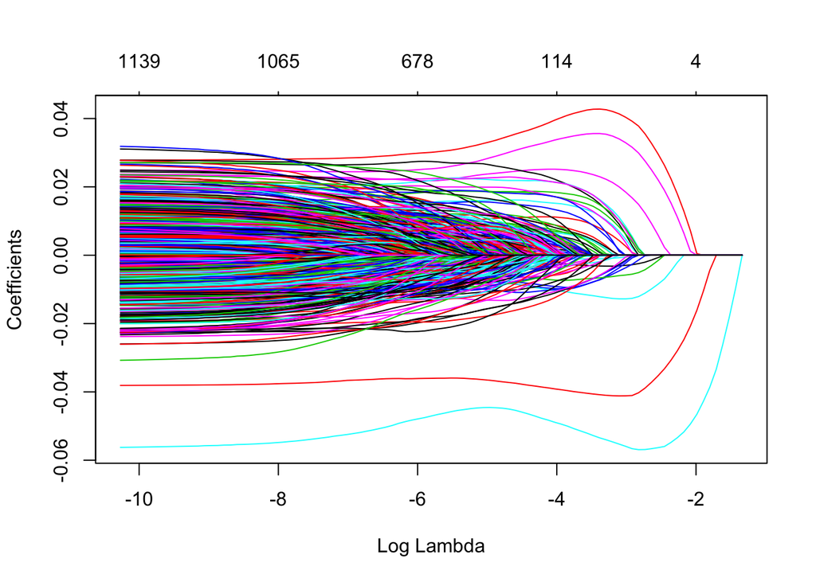

```r
out <- glmnet(X_train, y_train)
plot(out, xvar="lambda")
```

Let’s use cross validation and see how the model performs for prediction with various lambda values:

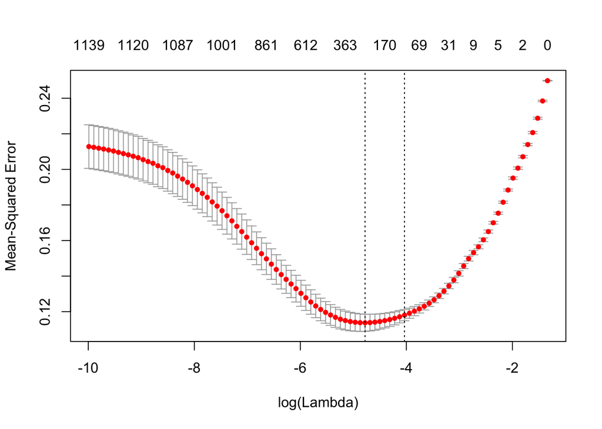

```r
out <- cv.glmnet(X_train, y_train)
plot(out)
```

Here we see, with a much more interesting prediction task, the balance between overfit (lambda too small; LHS) and underfit (lambda too large; RHS). The best predictions are right in the middle.

Let’s look at the non-zero components of the optimal (under cross-validation) lambda; the code here sorts the results from largest to smallest:

```r
beta <- as.matrix(coef(out))
beta <- beta[beta[,1] != 0,, drop=FALSE][-1,,drop=FALSE]
beta[order(beta[,1],decreasing=TRUE),,drop=FALSE]
```

```
##                         1
## taste        3.948745e-02
## flavor       3.367879e-02
## product      2.517352e-02
## These        2.227303e-02
## price        2.142172e-02
## tastes       2.137050e-02
## eat          1.840645e-02
## tasty        1.717794e-02
## delicious    1.717227e-02
## tasting      1.714449e-02
## use          1.521814e-02
## snack        1.336724e-02
## bag          1.119295e-02
## ordering     1.067924e-02
## flavors      8.879369e-03
## these        8.867634e-03
## buy          8.120764e-03
## my           7.454994e-03
## add          6.992688e-03
## Amazon       6.541552e-03
## flavorful    6.377457e-03
## butter       6.361025e-03
## like         6.100148e-03
## sweet        5.769927e-03
## brand        5.473757e-03
## container    5.440660e-03
## They         5.281891e-03
## free         5.189422e-03
## prefer       4.787160e-03
## favorite     4.695886e-03
## teas         4.460937e-03
## pack         4.375335e-03
## flavored     4.096391e-03
## package      4.004482e-03
## milk         3.764830e-03
## cereal       3.519833e-03
## box          3.185585e-03
## try          2.906533e-03
## tried        2.859422e-03
```

[output cut: 60 more lines]

```
## mystery     -5.634144e-03
## writing     -5.710560e-03
## into        -5.865289e-03
## who         -7.263066e-03
## young       -7.764861e-03
## by          -9.147855e-03
## funny       -9.280317e-03
## an          -9.757513e-03
## reading     -1.008803e-02
## story       -1.024816e-02
## stories     -1.062876e-02
## books       -1.111295e-02
## fun         -1.249243e-02
## read        -3.910256e-02
## book        -4.885116e-02
```

Do the terms make sense? Hopefully they do, at least the terms at the top and bottom of the vector. We can manually choose a larger value of lambda to have a more tractable set of coefficients to work with. This code uses the 15th largest lambda value:

```r
beta <- as.matrix(coef(out, s=out$lambda[15]))
beta <- beta[beta[,1] != 0,, drop=FALSE][-1,,drop=FALSE]
beta[order(beta[,1],decreasing=TRUE),,drop=FALSE]
```

```
##                    1
## taste    0.032730582
## flavor   0.024966633
## product  0.009264506
## his     -0.001403757
## who     -0.002996522
## story   -0.009863916
## read    -0.037182312
## book    -0.056614907
```

So, how well does the model do on predicting value on the validation set? The lasso regression returns a number, so we need to convert this to a category (more on this next time). I just picked the value of 0.5 for now to split the two categories.

```r
y_pred <- as.numeric(predict(out, s = out$lambda.min, newx = X) > 0.5)
```

And the mis-classification rate on the training and testing sets is….

```r
tapply((y == y_pred), amazon$train_id, mean)
```

```
##     train     valid
## 0.9748814 0.9618387
```

Fairly good! It’s correct about 97.5% of the time on the training set and 96% on the validation set.

## Your turn

Re-read the Amazon dataset with the following code; now, we include only the categories 0 (books) and 1 (movies). This is a harder prediction task:

```r
amazon <- read_csv("https://statsmaths.github.io/ml_data/amazon_product_class.csv")
amazon <- filter(amazon, !is.na(category), category %in% c(1, 3))
amazon$category <- as.numeric(factor(amazon$category)) - 1L
```

Copying the code from above, fit a lasso model on this dataset. See if the coefficients make sense to you and how well it works on the training and testing sets. Try to play around with the parameters for constructing the term frequency matrix and see if that helps at all.

Here, I will create the dataset:

```r
anno <- cnlp_get_token(cnlp_annotate(amazon, text_var = "text"))
```

```r
X <- cnlp_utils_tfidf(anno, min_df = 0.01, max_df = 0.5, tf_weight = "raw", token_var = "word")
y <- amazon$category
X_train <- X[amazon$train_id == "train",]
y_train <- y[amazon$train_id == "train"]
```

Then, run the model and show the exploratory results:

```r
out <- cv.glmnet(X_train, y_train)
beta <- as.matrix(coef(out, s=out$lambda[15]))
beta <- beta[beta[,1] != 0,, drop=FALSE][-1,,drop=FALSE]
beta[order(beta[,1],decreasing=TRUE),,drop=FALSE]
```

```
##                  1
## movie  0.034538371
## film   0.017107992
## DVD    0.002465094
## read  -0.037238707
## book  -0.057008024
```

And finally, show the prediction results:

```r
y_pred <- as.numeric(predict(out, s = out$lambda.min, newx = X) > 0.5)
tapply((y == y_pred), amazon$train_id, mean)
```

```
##     train     valid
## 0.9594980 0.9423729
```

Only slightly worse that the prior model; were you able to get better results by using a different model matrix?

When you are done, do the lab problems and return the final block of code.

### Lasso regression

Here, we’ll generate some random data with five columns. I included some code to make sure that the columns of X are slightly correlated, otherwise we would just get something that looked nearly the same as the case where XtX is equal to the identity.

```r
set.seed(1)
n <- 100
p <- 5
X <- matrix(rnorm(n * p), ncol = p)

# make the columns of X moderately correlated with one another
X[,2] <- X[,2] + X[,1] * 0.5
X[,3] <- X[,3] + X[,1] * 0.5
X[,4] <- X[,3] + X[,1] * 0.5

# construct simulated values y
b0 <- c(2, -2, -0.5, 0,  0)
y <- X %*% b0 + rnorm(n, sd=0.5)
```

The function below applies the coordinate descent algorithm to LASSO regression. You will need to fill in the two lines where indicated (right now it just sets beta[k] to 0; fill in the correct two expressions).

```r
run_coord_descent_lasso <- function(X, y, lambda=1, max_iter=100)
{
  beta <- rep(0, ncol(X))                 # initialize beta with all zeros

  for (i in seq_len(max_iter))            # run coordinate descent for at most max_iter runs
  {
    beta_old <- beta                      # store previous beta value
    for (k in seq_along(beta))            # cycle through the coordinates
    {
      beta[k] <- 0                        # initialize beta_k to zero
      r <- y - X %*% beta                 # this is partial residual, because beta_k = 0
      rtx <- t(r) %*% X[,k]               # correlation of X_k and partial residual

      if (rtx > lambda)
      {
        # Condition to update beta[k] if rtx is larger than lambda
        beta[k] <- (rtx - lambda) / (t(X[,k]) %*% X[,k])
      } else if (rtx < -1 * lambda) {
        # Condition to update beta[k] if rtx is less than -lambda
        beta[k] <- (rtx + lambda) / (t(X[,k]) %*% X[,k])
      }
    }

    # check if anything changed; if not exit loop and return the result
    if (sum((beta - beta_old)^2) < 1e-10) { break }
  }

  return(beta)
}
```

Now, run coordinate descent on the dataset for a value of lambda:

```r
run_coord_descent_lasso(X, y, lambda=70)
```

```
## [1]  0.2362873 -0.8328649  0.0000000  0.0000000  0.0000000
```

This should make only the first two coefficients non-zero; the signs match the values in `b0`, but both values are significantly smaller than in the simulation due to the soft-thresholding of the lasso penalty.

Finally, run this code to apply your function to a sequence of 200 lambda values and plot the results:

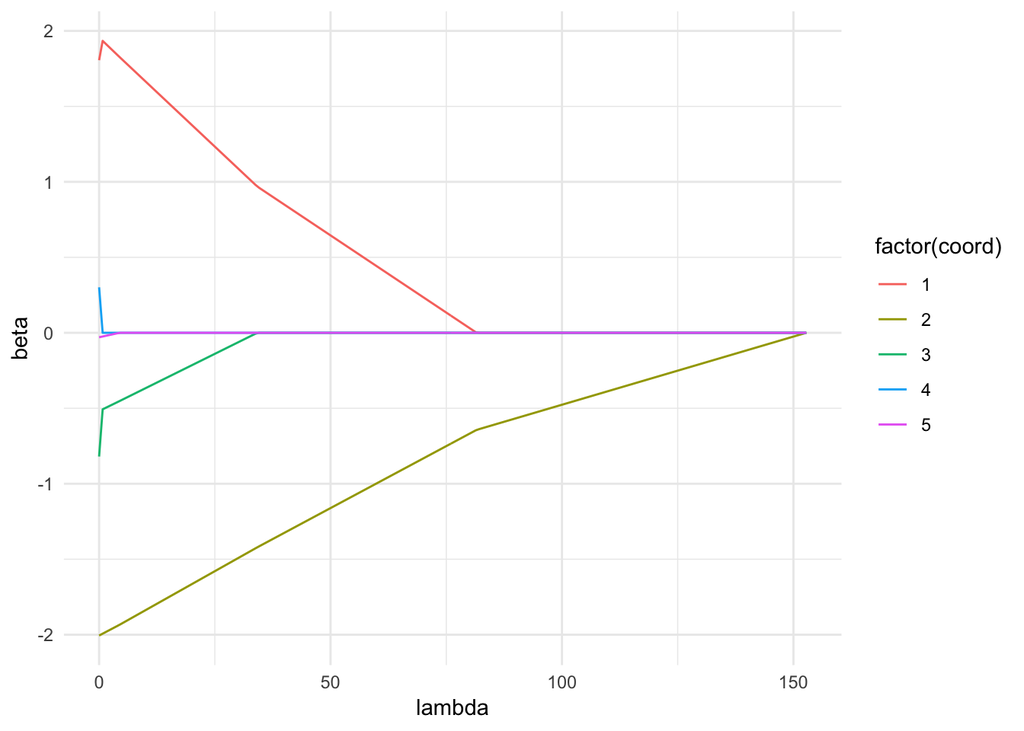

```r
N <- 200
max_lambda <- max(abs(t(X) %*% y))
lvals <- seq(0, max_lambda, length.out = N)

B <- matrix(0, ncol = ncol(X), nrow = N)
for (j in seq_len(N))
{
  B[j,] <- run_coord_descent_lasso(X, y, lambda=lvals[j])
}

paths <- tibble(lambda = rep(lvals, ncol(B)),
                beta = as.numeric(B),
                coord = rep(seq_len(ncol(X)), each=nrow(B)))

ggplot(paths, aes(lambda, beta)) +
  geom_line(aes(color = factor(coord)))
```

This should look a lot like the plot you had in the last class.